# NOOA Storm Research

Stefaan Delanghe

3 June 2016

## Synopsis

With this report we analyze the concequences of different weather events on the health of the population and the econcomy in the U.S. The NOAA has monitored data about weather events from 1950 till 2011. This data will be used to do our investigation. In order to determine the health concequences on the population we focus on injuries and fatalities from which we can conclude that Tornado’s and excessive heat are primary cause of fatalities and Tornado’s and TSTM winds for injuries. As far as the economic damages go the flood and hurricane are the two events causing the most damages to the economy.

## Introduction

The research that is described in this document is the exploration of the NOAA Storm database in light to answers some questions about severe weather events. Following questions are asked in regard to the Storm events and will be answered during the course of this document:

- Across the United States, which types of events (as indicated in the 𝙴𝚅𝚃𝚈𝙿𝙴 variable) are most harmful with respect to population health?
- Across the United States, which types of events have the greatest economic consequences?

## Data

The data for this research come in the form of a comma-separated-value file compressed via the bzip2 algorithm to reduce its size. [The data for the NOOA storm research can be download by clicking here](https://d396qusza40orc.cloudfront.net/repdata%2Fdata%2FStormData.csv.bz2)

The data has been provided to us by Coursera

Further documentation of the dataset is provided to us by the [National Weather Service](https://d396qusza40orc.cloudfront.net/repdata%2Fpeer2_doc%2Fpd01016005curr.pdf).

## Data Processing

```r
library(knitr)
library(ggplot2)
library(reshape2)
```

### Obtaining and loading

We load the encrypted NOAA Storm dataset. Due to amount of time it takes to load this dataset we cache this operation.

```r
data.storm <- read.csv("repdata-data-StormData.csv.bz2")
dim(data.storm)
```

```
## [1] 902297     37
```

```r
str(data.storm)
```

```
## 'data.frame':    902297 obs. of  37 variables:
##  $ STATE__   : num  1 1 1 1 1 1 1 1 1 1 ...
##  $ BGN_DATE  : Factor w/ 16335 levels "1/1/1966 0:00:00",..: 6523 6523 4242 11116 2224 2224 2260 383 3980 3980 ...
##  $ BGN_TIME  : Factor w/ 3608 levels "00:00:00 AM",..: 272 287 2705 1683 2584 3186 242 1683 3186 3186 ...
##  $ TIME_ZONE : Factor w/ 22 levels "ADT","AKS","AST",..: 7 7 7 7 7 7 7 7 7 7 ...
##  $ COUNTY    : num  97 3 57 89 43 77 9 123 125 57 ...
##  $ COUNTYNAME: Factor w/ 29601 levels "","5NM E OF MACKINAC BRIDGE TO PRESQUE ISLE LT MI",..: 13513 1873 4598 10592 4372 10094 1973 23873 24418 4598 ...
##  $ STATE     : Factor w/ 72 levels "AK","AL","AM",..: 2 2 2 2 2 2 2 2 2 2 ...
##  $ EVTYPE    : Factor w/ 985 levels "   HIGH SURF ADVISORY",..: 834 834 834 834 834 834 834 834 834 834 ...
##  $ BGN_RANGE : num  0 0 0 0 0 0 0 0 0 0 ...
##  $ BGN_AZI   : Factor w/ 35 levels "","  N"," NW",..: 1 1 1 1 1 1 1 1 1 1 ...
##  $ BGN_LOCATI: Factor w/ 54429 levels ""," Christiansburg",..: 1 1 1 1 1 1 1 1 1 1 ...
##  $ END_DATE  : Factor w/ 6663 levels "","1/1/1993 0:00:00",..: 1 1 1 1 1 1 1 1 1 1 ...
##  $ END_TIME  : Factor w/ 3647 levels ""," 0900CST",..: 1 1 1 1 1 1 1 1 1 1 ...
##  $ COUNTY_END: num  0 0 0 0 0 0 0 0 0 0 ...
```

[output cut: 23 more lines]

```r
data.storm$YEAR <- as.numeric(format(as.Date(data.storm$BGN_DATE, format = "%m/%d/%Y %H:%M:%S"), "%Y"))
```

### Most harmfull events

As based on the provided documentation we consider injuries and fatalities as harmfull. By this we combine injuries and fatalities by event type. So following columns are relevant to answer this question

| Column | Description |
| --- | --- |
| YEAR | Year in which the event to place |
| EVTYPE | The event type |
| INJURIES | Number of registered injuries for this event |
| FATALITIES | Number of registered fatalities for this event |

The number of fatilities by event type is represented in data.fatalities along we with it’s total.

```r
data.fatalities <- aggregate(data.storm$FATALITIES, by =list(EventType=data.storm$EVTYPE) , FUN =sum)
sum(data.fatalities$x)
```

```
## [1] 15145
```

The number of injuries by event type is represented in data.injuries along we with it’s total.

```r
data.injuries <- aggregate(data.storm$INJURIES, by =list(EventType=data.storm$EVTYPE) , FUN =sum)
sum(data.injuries$x)
```

```
## [1] 140528
```

The number of harmfull (injuries and fatalities) by event type is represented in data.harmfull along we with it’s total.

```r
data.harmfull <- rbind(data.injuries,data.fatalities)
sum(data.harmfull$x)
```

```
## [1] 155673
```

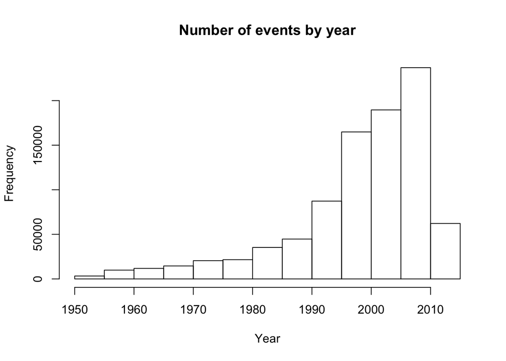

```r
hist(data.storm$YEAR, xlab = "Year", main = "Number of events by year")
```

### Economic consequences

First we process our data which are relevant to determine the economic consequences. The property and crop values are deterministic for the economic concequences. We require following columns to determine the economic consequences.

| Column | Description |
| --- | --- |
| YEAR | Year in which the event to place |
| EVTYPE | The event type |
| PROPDMG | Registered property damage in numbers |
| PROPDMGEXP | Expressed value of PROPDMG - Hundred (H), Thousand (T), Million (M), Billion (B) |
| CROPDMG | Registered crops damage in numbers |
| CROPDMGEXP | Expressed value of CROPDMG - Hundred (H), Thousand (T), Million (M), Billion (B) |

As the property and crop damagages are expressed in different exponents we have to express all the values in one unit. Here follows a list of the different units for property and crops.

```r
levels(data.storm$PROPDMGEXP)
```

```
##  [1] ""  "-" "?" "+" "0" "1" "2" "3" "4" "5" "6" "7" "8" "B" "h" "H" "K"
## [18] "m" "M"
```

```r
levels(data.storm$CROPDMGEXP)
```

```
## [1] ""  "?" "0" "2" "B" "k" "K" "m" "M"
```

We map the exponent to a number back into a seperated column. All number and non alfabethic characters are set to a number 1

```r
data.storm$CROPDMGEXPN <- 0
data.storm$CROPDMGEXPN[grep("[?+-012345678]", data.storm$CROPDMGEXP, ignore.case=TRUE)] <- 1
data.storm$CROPDMGEXPN[grep("[h]", data.storm$CROPDMGEXP, ignore.case=TRUE)] <- 100
data.storm$CROPDMGEXPN[grep("[k]", data.storm$CROPDMGEXP, ignore.case=TRUE)] <- 1e+03
data.storm$CROPDMGEXPN[grep("[m]", data.storm$CROPDMGEXP, ignore.case=TRUE)] <- 1e+06
data.storm$CROPDMGEXPN[grep("[b]", data.storm$CROPDMGEXP, ignore.case=TRUE)] <- 1e+09

data.storm$PROPDMGEXPN <- 0
data.storm$PROPDMGEXPN[grep("[?+-012345678]", data.storm$PROPDMGEXP, ignore.case=TRUE)] <- 1
data.storm$PROPDMGEXPN[grep("[h]", data.storm$PROPDMGEXP, ignore.case=TRUE)] <- 100
data.storm$PROPDMGEXPN[grep("[k]", data.storm$PROPDMGEXP, ignore.case=TRUE)] <- 1e+03
data.storm$PROPDMGEXPN[grep("[m]", data.storm$PROPDMGEXP, ignore.case=TRUE)] <- 1e+06
data.storm$PROPDMGEXPN[grep("[b]", data.storm$PROPDMGEXP, ignore.case=TRUE)] <- 1e+09
```

Now we calculate the damage to crop and property by the exponent number column (…EXPN). Total is stored in (…DMGT)

```r
data.storm$CROPDMGT <- data.storm$CROPDMG * data.storm$CROPDMGEXPN
sum(data.storm$CROPDMGT)
```

```
## [1] 49104192170
```

```r
data.storm$PROPDMGT <- data.storm$PROPDMG * data.storm$PROPDMGEXPN
sum(data.storm$PROPDMGT)
```

```
## [1] 427318652444
```

The total damages to the economy are

```r
data.storm$DMGT <- data.storm$CROPDMGT + data.storm$PROPDMGT
sum(data.storm$DMGT)
```

```
## [1] 476422844614
```

Now we calculate the total amount of damages for event types (for crops,property and combined)

```r
cropDamages <- with(data.storm, aggregate(CROPDMGT ~ EVTYPE, FUN = sum))
head(cropDamages[order(-cropDamages$CROPDMGT),])
```

```
##          EVTYPE    CROPDMGT
## 95      DROUGHT 13972566000
## 170       FLOOD  5661968450
## 590 RIVER FLOOD  5029459000
## 427   ICE STORM  5022113500
## 244        HAIL  3025954470
## 402   HURRICANE  2741910000
```

```r
propDamages <- with(data.storm, aggregate(PROPDMGT ~ EVTYPE, FUN = sum))
head(propDamages[order(-propDamages$PROPDMGT),])
```

```
##                EVTYPE     PROPDMGT
## 170             FLOOD 144657709800
## 411 HURRICANE/TYPHOON  69305840000
## 834           TORNADO  56937160776
## 670       STORM SURGE  43323536000
## 153       FLASH FLOOD  16140811860
## 244              HAIL  15732267486
```

## Results

Our data processing answers two questions which are described below.

### Most harmfull type of events

Across the United States, which types of events (as indicated in the 𝙴𝚅𝚃𝚈𝙿𝙴 variable) are most harmful with respect to population health? Answer: As we can not determine if a fatality or injury is directlly caused by a event, we need to mention that also indirect causes are included in the calculations.

Here a the number of injuries per event type sorted by higest number. Only the top 10 is displayed.

```r
data.injurytype <- data.injuries[order(-data.injuries$x),]
data.injurytypeTop <- data.injurytype[data.injurytype$x>0,]
names(data.injurytypeTop) <- c("EventType","Injuries")
head(data.injurytypeTop, n = 10)
```

```
##             EventType Injuries
## 834           TORNADO    91346
## 856         TSTM WIND     6957
## 170             FLOOD     6789
## 130    EXCESSIVE HEAT     6525
## 464         LIGHTNING     5230
## 275              HEAT     2100
## 427         ICE STORM     1975
## 153       FLASH FLOOD     1777
## 760 THUNDERSTORM WIND     1488
## 244              HAIL     1361
```

Here a the number of fatalities per event type sorted by higest number. Only the top 10 is displayed.

```r
data.fatalitytype <- data.fatalities[order(-data.fatalities$x),]
data.fatalitytypeTop <- data.fatalitytype[data.fatalitytype$x>0,]
names(data.fatalitytypeTop) <- c("EventType","Fatalities")
head(data.fatalitytypeTop, n = 10)
```

```
##          EventType Fatalities
## 834        TORNADO       5633
## 130 EXCESSIVE HEAT       1903
## 153    FLASH FLOOD        978
## 275           HEAT        937
## 464      LIGHTNING        816
## 856      TSTM WIND        504
## 170          FLOOD        470
## 585    RIP CURRENT        368
## 359      HIGH WIND        248
## 19       AVALANCHE        224
```

As we can see Tornado’s are the primary weather event that causes a harmfull threath to the populations health.

### Greatest economic consequences

Across the United States, which types of events have the greatest economic consequences?

Based on the combined damages we see that flood and hurricane/typhoon are the two event causing the most economic damages.

```r
totalDamages <- with(data.storm, aggregate(DMGT ~ EVTYPE, FUN = sum))
head(totalDamages[order(-totalDamages$DMGT),])
```

```
##                EVTYPE         DMGT
## 170             FLOOD 150319678250
## 411 HURRICANE/TYPHOON  71913712800
## 834           TORNADO  57352114046
## 670       STORM SURGE  43323541000
## 244              HAIL  18758221956
## 153       FLASH FLOOD  17562128960
```